# Bathymetric maps in R

## ggplot2

`ggplot2` doesn’t use `R`‘s basic graphical functions (at least at the surface), but instead uses a different ’grammer of graphics’ (hence ‘gg’) syntax for plotting. As a result, the plotting philosophy and coding syntax are quite different. This can create a bit of a learning curve at first, but offers a lot of incredibly powerful features. Here’s a quick example:

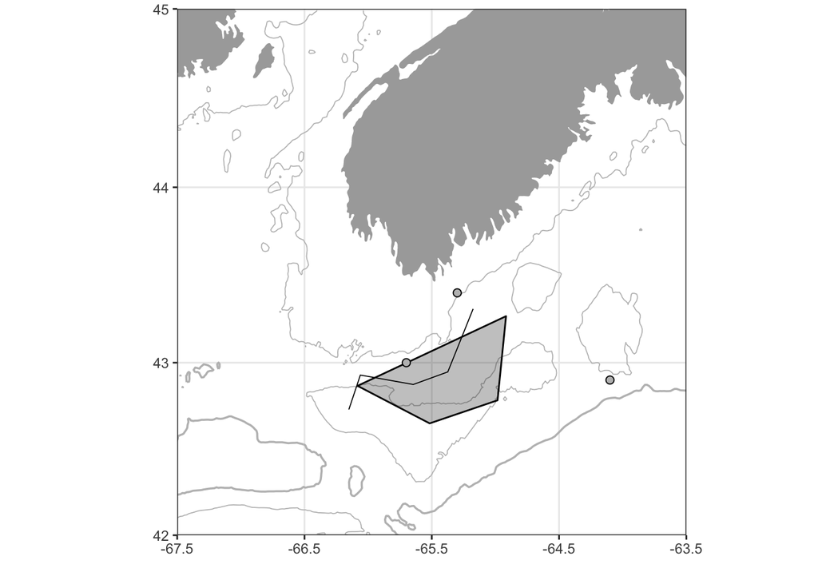

```r
library(ggplot2)
library(mapdata)

# convert bathymetry to data frame
bf = fortify.bathy(b)

# get regional polygons
reg = map_data("world2Hires")
reg = subset(reg, region %in% c('Canada', 'USA'))

# convert lat longs
reg$long = (360 - reg$long)*-1

# set map limits
lons = c(-67.5, -63.5)
lats = c(42, 45)

# make plot
ggplot()+

  # add 100m contour
  geom_contour(data = bf,
               aes(x=x, y=y, z=z),
               breaks=c(-100),
               size=c(0.3),
               colour="grey")+

  # add 250m contour
  geom_contour(data = bf,
               aes(x=x, y=y, z=z),
               breaks=c(-250),
               size=c(0.6),
               colour="grey")+

  # add coastline
  geom_polygon(data = reg, aes(x = long, y = lat, group = group),
               fill = "darkgrey", color = NA) +

  # add polygon
  geom_polygon(data = ply, aes(x = lon, y = lat),
               color = "black", alpha = 0.3) +

  # add line
  geom_path(data = lin, aes(x = lon, y = lat),
            colour = "black", alpha = 1, size=0.3)+

  # add points
  geom_point(data = pts, aes(x = lon, y = lat),
             colour = "black", fill = "grey",
             stroke = .5, size = 2,
             alpha = 1, shape = 21)+

  # configure projection and plot domain
  coord_map(xlim = lons, ylim = lats)+

  # formatting
  ylab("")+xlab("")+
  theme_bw()
```

Pretty nice! One issue I still have with this map is that I haven’t been able to find an elegant way to add labels to the contour lines. There are ways to do this in normal `ggplot2` contour plots (like with the `direct.label` package), but these fail with projected data. Perhaps I’ll file an issue with the developers to see if they can shed any light.

## Summary

Both `oce` and `ggplot2` offer simple, accurate, and elegent tools for plotting bathymetric data. I’m newer to `ggplot2` for mapping, but I’m quite impressed with its capabilities. I suspect I’ll continue to use `oce` for quickly plotting results on the fly, but will definitely begin to use and explore `ggplot2` for presentation and publication quality visuals.